# KoLab R Study Week5

May 9, 2019

## Week5

## Data loading

```r
library(readxl)
# setwd("C:/Users/a0728/Dropbox/study/R_study/19.03.28_R_study (Kolab)")
w3 <- read_xlsx("Week3_example1.xlsx")
```

## Functions

### Function (함수)

- 프로그래밍의 핵심 요소
- 컴퓨터에게 특정한 과제를 시키는 역할 *(cf. 변수는 자료를 저장하는 역할)*
- in-built functions / custom functions

## Functions

### in-built functions

- 지금까지 배운 많은 함수들
  - ex. ?

## Functions

### custome functions

- 사용자가 임의로 함수를 정의할 수 있음

```r
function_name <- function(arg1, arg2, ...) {
    function codes
}
```

## Functions

```r
function_name <- function(arg1, arg2, ...) {
    function body
}
```

```r
standardizer <- function(data){
    z <- (data - mean(data, na.rm=T)) / sd(data, na.rm = T)
    z
}
```

- function_name: standardize
  - 임의로 지정할 수 있음.
  - 이 이름을 통해 R enviornment의 object(객체)로 저장됨
- argument: 함수가 실행될 때, 해당 argument 자리에 우리가 입력한 값이 코드에 입력됨
- function body: 함수가 수행해야 할 것을 모아놓은 code
- return value: 함수의 결과로 출력되는 값. R에서는 마지막 줄

## Functions

- argument maching

```r
mydivision <- function(first_num, second_num) {
    first_num / second_num
}
mydivision(2, 4)
```

```
## [1] 0.5
```

```r
mydivision <- function(a, b) {
    a / b
}
mydivision(2, 4)
```

```
## [1] 0.5
```

## Functions

- argument maching

```r
mydivision <- function(a, b) {
    a / b
}
mydivision(2, 4)
```

```
## [1] 0.5
```

```r
mydivision <- function(a, b) {
    a / b
}
mydivision(b = 4, a = 2)
```

```
## [1] 0.5
```

## Functions

- argument: default

```r
mydivision <- function(a = 2, b = 4) {
    a / b
}
mydivision()
```

```
## [1] 0.5
```

## Functions

```r
standardizer <- function(data) {
    (data - mean(data, na.rm = T)) / sd(data, na.rm = T)
}
standardizer(w3$emo.wb) # 결과1
```

```
##   [1] -0.38460  0.21025  0.21025  0.80509  1.69735  1.69735  0.80509 -0.08718
##   [9]  1.10251 -0.08718 -0.08718 -0.68202  0.21025 -0.68202  1.10251 -0.08718
##  [17]  0.80509 -1.57428 -0.68202 -0.97944  0.50767  0.80509 -0.68202  1.39993
##  [25]  0.21025 -1.87170 -0.38460  0.21025 -0.08718 -0.38460  0.80509 -1.57428
##  [33] -1.87170 -0.08718  0.21025  0.80509 -0.68202  0.50767  0.80509 -1.57428
##  [41]  1.39993 -0.08718 -0.68202 -0.08718  0.21025  0.50767  1.10251 -0.08718
##  [49] -0.68202 -0.08718 -0.08718  0.21025  0.80509 -0.68202 -0.08718  1.69735
##  [57]  0.21025 -0.97944  1.10251 -0.38460 -0.68202  0.50767  0.50767  0.80509
##  [65]  1.39993 -1.87170  0.80509 -2.16912  1.10251 -1.27686  0.50767  0.50767
##  [73] -0.68202  0.80509 -1.27686 -2.76396 -0.38460  1.69735  1.10251  0.50767
##  [81]  0.80509 -2.46654  0.80509  0.21025  1.69735 -0.08718 -1.57428  1.10251
##  [89]  0.21025 -0.68202 -1.87170  0.21025 -0.08718  1.69735 -0.97944 -0.08718
##  [97] -0.97944  0.80509  0.21025 -0.38460 -1.57428 -1.57428  0.80509 -0.08718
## [105]  0.50767  0.80509  0.80509 -1.87170 -1.27686 -0.08718  0.80509  0.80509
## [113]  1.39993 -0.68202 -0.08718 -0.08718
```

```r
standardizer <- function(data) {
    z <- (data - mean(data, na.rm = T)) / sd(data, na.rm = T)
    z
}
standardizer(w3$emo.wb) # 결과2
```

```
##   [1] -0.38460  0.21025  0.21025  0.80509  1.69735  1.69735  0.80509 -0.08718
##   [9]  1.10251 -0.08718 -0.08718 -0.68202  0.21025 -0.68202  1.10251 -0.08718
##  [17]  0.80509 -1.57428 -0.68202 -0.97944  0.50767  0.80509 -0.68202  1.39993
##  [25]  0.21025 -1.87170 -0.38460  0.21025 -0.08718 -0.38460  0.80509 -1.57428
##  [33] -1.87170 -0.08718  0.21025  0.80509 -0.68202  0.50767  0.80509 -1.57428
##  [41]  1.39993 -0.08718 -0.68202 -0.08718  0.21025  0.50767  1.10251 -0.08718
##  [49] -0.68202 -0.08718 -0.08718  0.21025  0.80509 -0.68202 -0.08718  1.69735
##  [57]  0.21025 -0.97944  1.10251 -0.38460 -0.68202  0.50767  0.50767  0.80509
##  [65]  1.39993 -1.87170  0.80509 -2.16912  1.10251 -1.27686  0.50767  0.50767
##  [73] -0.68202  0.80509 -1.27686 -2.76396 -0.38460  1.69735  1.10251  0.50767
##  [81]  0.80509 -2.46654  0.80509  0.21025  1.69735 -0.08718 -1.57428  1.10251
##  [89]  0.21025 -0.68202 -1.87170  0.21025 -0.08718  1.69735 -0.97944 -0.08718
##  [97] -0.97944  0.80509  0.21025 -0.38460 -1.57428 -1.57428  0.80509 -0.08718
## [105]  0.50767  0.80509  0.80509 -1.87170 -1.27686 -0.08718  0.80509  0.80509
## [113]  1.39993 -0.68202 -0.08718 -0.08718
```

## Functions

```r
z
```

```
## Error in eval(expr, envir, enclos): 객체 'z'를 찾을 수 없습니다
```

- 함수 안에서 일어난 일은 함수 안의 일
- R environment에 영향을 주지 않음
- 함수의 결과를 입력하려면?

## Functions

```r
w3$emo.em.z <- standardizer(w3$emo.em)
w3$emo.em.z
```

```
##   [1] -0.638226 -0.216379 -0.849149  0.627316  0.627316 -1.270996 -1.060073
##   [8]  0.416392  1.892857 -0.849149 -0.427302 -0.427302  1.049163 -1.481920
##  [15]  0.205469 -1.481920 -0.427302  0.627316  0.205469 -2.536538 -1.060073
##  [22] -0.849149 -0.638226 -0.216379 -0.216379  2.314705 -0.427302 -1.270996
##  [29] -0.638226  0.416392 -1.060073 -1.481920 -0.005455 -1.270996  0.838239
##  [36]  0.627316 -0.216379  0.205469  0.205469  0.205469 -0.638226 -0.638226
##  [43] -0.005455  1.049163 -1.060073 -0.638226 -0.216379  1.260087 -1.060073
##  [50] -0.849149 -0.005455 -0.005455 -2.114691 -1.060073  0.416392 -0.216379
##  [57] -1.692844 -0.638226  0.627316 -0.216379  0.416392  0.205469  0.205469
##  [64] -1.270996  1.471010 -0.849149 -1.903767  0.416392 -0.638226  0.416392
##  [71] -0.427302  0.627316  0.416392  0.838239 -1.270996  1.471010  0.627316
##  [78]  1.892857 -0.427302 -0.849149  0.627316  1.471010 -0.427302 -0.849149
##  [85] -0.638226 -0.005455 -0.216379  0.205469 -0.216379  2.103781  1.260087
##  [92] -1.692844  1.260087  0.205469  0.627316  1.049163  0.838239 -0.638226
##  [99]  1.049163  1.260087  1.049163  0.205469  1.471010  1.049163 -0.216379
## [106]  0.627316  1.681934 -1.481920  2.314705 -0.638226  1.892857  0.627316
## [113]  0.416392  1.049163 -0.427302 -0.005455
```

## Functions

- 직접 함수를 만들어 봅시다!
- 분석하면서 필요한 함수는??

## Automated correlation plotting

## Apply function

`data[, sapply(data, is.numeric)]`

## Apply function

- **Quiz.** 모든 변인의 최대값을 알고 싶으면 어떻게 할까요? (1p)

## Apply function

- **Quiz.** 모든 변인의 최대값을 알고 싶으면 어떻게 할까요? (1p)

```r
for (i in 1:dim(w3)[2]){
    m <- max(w3[[i]])
    print(m)
}
```

```
## [1] 116
## [1] 2
## [1] 15
## [1] 25
## [1] 29
## [1] "플로리시"
## [1] 128
## [1] 74
## [1] 68
## [1] 44
## [1] 47
## [1] 43
## [1] 103
## [1] 113
## [1] 160
## [1] 2.315
```

## Apply function

```r
apply(w3, 2, max)
```

```
##          ID      gender      emo.wb      soc.wb      psy.wb     cate.wb
##       "116"         "2"        "15"        "25"        "29"  "플로리시"
##     soc.int     emo.int      cog.em      emo.em        mach         dep
##       "128"        "74"        "68"        "44"        "47"        "43"
##     anx.att     avo.att          rs    emo.em.z
##       "103"       "113"       "160" " 2.314705"
```

## Apply function

- more easier

```r
sapply(w3,max)
```

```
##                 ID             gender             emo.wb             soc.wb
##              "116"                "2"               "15"               "25"
##             psy.wb            cate.wb            soc.int            emo.int
##               "29"         "플로리시"              "128"               "74"
##             cog.em             emo.em               mach                dep
##               "68"               "44"               "47"               "43"
##            anx.att            avo.att                 rs           emo.em.z
##              "103"              "113"              "160" "2.31470461987263"
```

## Apply function

- For loop보다 코드가 간결하고 속도가 빠르다
- apply(데이터, 방향, 함수)
  - 방향: 행 = 1, 열 = 2
  - 함수: 원하는 함수 입력

## Apply function

```r
sapply(w3, is.numeric)
```

```
##       ID   gender   emo.wb   soc.wb   psy.wb  cate.wb  soc.int  emo.int
##     TRUE     TRUE     TRUE     TRUE     TRUE    FALSE     TRUE     TRUE
##   cog.em   emo.em     mach      dep  anx.att  avo.att       rs emo.em.z
##     TRUE     TRUE     TRUE     TRUE     TRUE     TRUE     TRUE     TRUE
```

- **Quiz.** 이 결과가 의미하는 것은 무엇일까요? (1p)
- **Quiz.** `data[, sapply(data, is.numeric)]`의 결과가 의미하는 것은 무엇일까요? (2p)

## Fonts

- showtext()
  - 구글에서 글꼴을 다운받아 바로 R에 장착
  - https://fonts.google.com/

## Fonts

```r
library(showtext)
windows() # if your local os is Windows
# x11() # if your local os is Macos
font_add_google("Lobster", "lobster")
plot(
    w3$emo.wb,
    w3$psy.wb,
    main = "Pretty Fonts",
    family = "lobster",
    cex.lab = 2,
    cex.axis = 1.5,
    cex.main = 2
    )
```

## Fonts

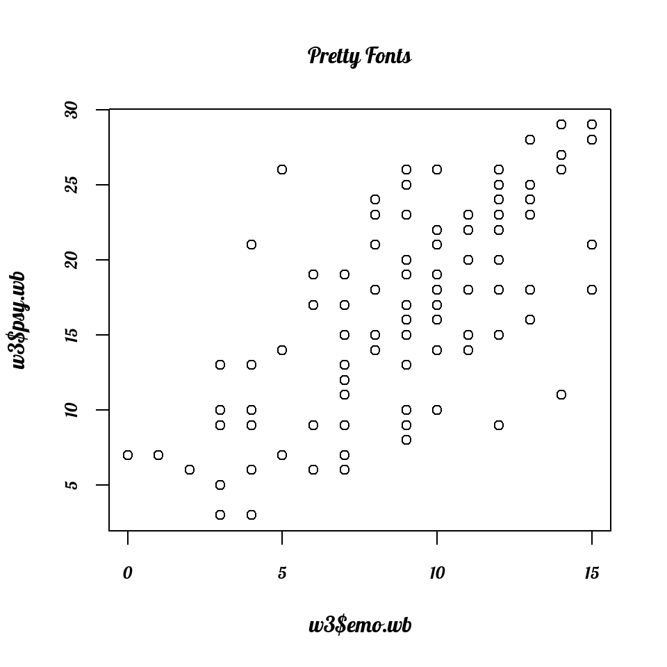

## Fonts

```r
font_add_google("Nanum Pen Script", "nanum_pen")
plot(
    w3$emo.wb,
    w3$psy.wb,
    main = "정서적 웰빙 & 심리적 웰빙",
    family = "nanum_pen",
    cex.lab = 2,
    cex.axis = 1.5,
    cex.main = 2
    )
```

## Fonts

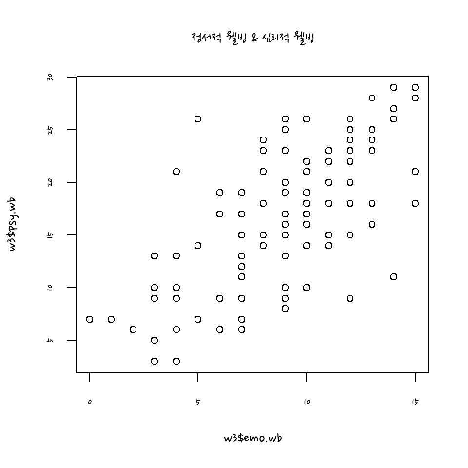

## Regression Analysis

## Simple Regression

```r
m1 <- lm(종속변인 ~ 독립변인1, data)
summary(m1)
```

## Multiple Regression

```r
m1 <- lm(종속변인 ~ 독립변인1 + 독립변인2 + 통제변인, data)
summary(m1)
```

## Multiple Regression

```r
m1 <- lm(rs ~ psy.wb + emo.wb, w3)
summary(m1)
```

```
##
## Call:
## lm(formula = rs ~ psy.wb + emo.wb, data = w3)
##
## Residuals:
##    Min     1Q Median     3Q    Max
## -56.31 -11.92   1.81  14.05  28.31
##
## Coefficients:
##             Estimate Std. Error t value Pr(>|t|)
## (Intercept) 107.4564     5.2165   20.60   <2e-16 ***
## psy.wb        0.0832     0.3487    0.24   0.8117
## emo.wb        2.1226     0.6849    3.10   0.0024 **
## ---
## Signif. codes:  0 '***' 0.001 '**' 0.01 '*' 0.05 '.' 0.1 ' ' 1
##
## Residual standard error: 18.1 on 113 degrees of freedom
## Multiple R-squared:  0.149,  Adjusted R-squared:  0.134
## F-statistic:  9.9 on 2 and 113 DF,  p-value: 0.000109
```

## Multiple Regression

- **Quiz.** 우울을 통제한 이후에도 관계 만족도를 유의하게 예측하는 독립변수를 찾아보세요. (3p)

## Multiple Regression

- **Quiz.** 우울을 통제한 이후에도 관계 만족도를 유의하게 예측하는 독립변수를 찾아보세요. (3p)

```r
whole.result <- data.frame()
for (i in 1:length(w3)) {
    m1 <- lm(rs ~ w3[[i]] + dep, w3)
    r <- summary(m1)
    p <- r$coefficients[2, 4]
    b <- r$coefficients[2, 1]

    if (p < 0.05) {
    p <- round(p, 2)
    b <- round(b, 2)
    result <- data.frame(names(w3)[i], b, p)
    whole.result <- rbind(whole.result, result)
    }
}
names(whole.result) <- c("Variable","b","p")
```

```r
print(whole.result)
```

```
##   Variable     b    p
## 1   cog.em  0.63 0.05
## 2      dep -0.80 0.00
## 3       rs  1.00 0.00
```

## RM ANOVA & Plotting

## Long formatted data

- Couple data
  - relationship satisfaction
  - facial valence
  - etc.

```r
w5 <- read_xlsx("Week5_data.xlsx")
str(w5)
```

```
## Classes 'tbl_df', 'tbl' and 'data.frame':    96 obs. of  27 variables:
##  $ C.ID                     : chr  "02" "02" "06" "06" ...
##  $ ID                       : chr  "02.1" "02.2" "06.1" "06.2" ...
##  $ partner.ID               : chr  "02.2" "02.1" "06.2" "06.1" ...
##  $ sex                      : chr  "1" "0" "1" "0" ...
##  $ age                      : num  23 23 25 23 25 20 20 19 28 25 ...
##  $ relationship.duration    : num  53 53 12 12 12 12 4 4 20 20 ...
##  $ relationship.persistence : num  1 1 1 1 1 1 1 1 1 1 ...
##  $ relationship.satisfaction: num  31 38 40 34 25 21 26 23 19 27 ...
##  $ explicit.accommodation   : num  123 94 88 96 107 60 95 80 117 105 ...
##  $ p_angry_facial_valence   : num  20.9 13.4 60.5 45.7 -16.8 ...
##  $ p_happy_facial_valence   : num  59.03 39.53 -1.79 46.74 39.21 ...
##  $ p_neutral_facial_valence : num  23.4 17.6 36.8 68 31.9 ...
##  $ o_angry_facial_valence   : num  7.62 -5.67 14.55 -9.71 -1.9 ...
##  $ o_happy_facial_valence   : num  -3.4352 36.202 -5.717 50.5794 -0.0102 ...
##  $ o_neutral_facial_valence : num  -1.72 -7.09 -5.23 -1.61 7.86 ...
##  $ p.angry.sub.perception   : num  3 1 4 8 2 7 3 3 5 5 ...
##  $ p.happy.sub.perception   : num  9 8 8 9 7 7 9 7 7 8 ...
##  $ p.neutral.sub.perception : num  7 7 7 7 7 7 7 5 7 6 ...
##  $ o.angry.sub.perception   : num  5 3 3 5 5 7 3 2 3 5 ...
##  $ o.happy.sub.perception   : num  7 6 7 5 6 7 7 3 7 7 ...
##  $ o.neutral.sub.perception : num  5 5 6 5 6 5 5 4 5 5 ...
##  $ eval.part.angry.val      : num  7 5 3 9 5 4 5 4 6 3 ...
##  $ eval.part.angry.likab    : num  5 4 4 7 7 6 4 4 6 2 ...
##  $ eval.part.happy.val      : num  7 6 7 5 7 7 6 6 7 7 ...
##  $ eval.part.happy.likab    : num  6 4 5 5 4 7 6 6 7 6 ...
##  $ eval.part.neutral.val    : num  5 7 9 5 6 5 4 3 6 7 ...
##  $ eval.part.neutral.likab  : num  4 5 7 7 1 7 4 3 5 6 ...
```

## Reshape2()

```r
library(reshape2)
long <- melt(data[, 사용열], id=c(만들열))
```

## Reshape2()

- 예시

```r
library(reshape2)
long <-
    melt(w5[, c(
    "ID","age",
    "p_happy_facial_valence",
    "p_neutral_facial_valence",
    "p_angry_facial_valence",
    "o_happy_facial_valence",
    "o_neutral_facial_valence",
    "o_angry_facial_valence"
    )], id =  c("ID","age"))
long
```

```
##       ID age                 variable      value
## 1   02.1  23   p_happy_facial_valence  5.903e+01
## 2   02.2  23   p_happy_facial_valence  3.953e+01
## 3   06.1  25   p_happy_facial_valence -1.794e+00
## 4   06.2  23   p_happy_facial_valence  4.674e+01
## 5   07.1  25   p_happy_facial_valence  3.921e+01
## 6   07.2  20   p_happy_facial_valence  1.877e+01
## 7   08.1  20   p_happy_facial_valence  9.885e+01
## 8   08.2  19   p_happy_facial_valence  6.451e+01
## 9   11.1  28   p_happy_facial_valence  7.401e+01
## 10  11.2  25   p_happy_facial_valence  9.944e+01
## 11  12.1  24   p_happy_facial_valence  7.639e+01
## 12  12.2  23   p_happy_facial_valence  6.582e+01
## 13  15.1  28   p_happy_facial_valence -2.830e+00
## 14  15.2  27   p_happy_facial_valence  1.316e-01
```

[output cut: 562 more lines]

## RM ANOVA

- Column이 총 4개
  - ID, age, variable, value
- Target과 Emotion 조건은 어떻게 추가하지?

```r
head(long)
```

```
##     ID age               variable  value
## 1 02.1  23 p_happy_facial_valence 59.026
## 2 02.2  23 p_happy_facial_valence 39.529
## 3 06.1  25 p_happy_facial_valence -1.794
## 4 06.2  23 p_happy_facial_valence 46.740
## 5 07.1  25 p_happy_facial_valence 39.207
## 6 07.2  20 p_happy_facial_valence 18.769
```

## RM ANOVA

- variable에서 factor를 추출해야 한다.
- `substr()` : data에서 특정 위치에 있는 문자 추출

```r
long$target <- as.factor(substr(long$variable, 1, 1))
long$emotion <- as.factor(substr(long$variable,3,5))
head(long)
```

```
##     ID age               variable  value target emotion
## 1 02.1  23 p_happy_facial_valence 59.026      p     hap
## 2 02.2  23 p_happy_facial_valence 39.529      p     hap
## 3 06.1  25 p_happy_facial_valence -1.794      p     hap
## 4 06.2  23 p_happy_facial_valence 46.740      p     hap
## 5 07.1  25 p_happy_facial_valence 39.207      p     hap
## 6 07.2  20 p_happy_facial_valence 18.769      p     hap
```

## RM ANOVA

- `aov_ez()`

```r
library(afex)
m1 <-
    aov_ez(
    id = "ID",
    dv = "value",
    within = c("target", "emotion"),
    data = long
    )
summary(m1)
```

```
##
## Univariate Type III Repeated-Measures ANOVA Assuming Sphericity
##
##                Sum Sq num Df Error SS den Df F value Pr(>F)
## (Intercept)    193573      1   180449     95  101.91 <2e-16 ***
## target         111040      1    77290     95  136.48 <2e-16 ***
## emotion         69420      2   113750    190   57.98 <2e-16 ***
## target:emotion   6513      2   115891    190    5.34 0.0055 **
## ---
## Signif. codes:  0 '***' 0.001 '**' 0.01 '*' 0.05 '.' 0.1 ' ' 1
##
##
## Mauchly Tests for Sphericity
##
##                Test statistic p-value
## emotion                 0.922  0.0217
## target:emotion          0.966  0.2009
##
##
## Greenhouse-Geisser and Huynh-Feldt Corrections
##  for Departure from Sphericity
##
##                GG eps Pr(>F[GG])
## emotion         0.927     <2e-16 ***
## target:emotion  0.968     0.0061 **
## ---
## Signif. codes:  0 '***' 0.001 '**' 0.01 '*' 0.05 '.' 0.1 ' ' 1
##
##                HF eps Pr(>F[HF])
## emotion        0.9451  2.108e-19
## target:emotion 0.9873  5.753e-03
```

## RM ANOVA

- RM ANOVA

```r
library(emmeans)
```

```r
post.hoc <- emmeans(m1, specs = c("target","emotion"))
pairs(post.hoc)
```

```
##  contrast      estimate   SE  df t.ratio p.value
##  o,ang - p,ang   -20.81 3.76 279  -5.538 <.0001
##  o,ang - o,hap   -23.60 3.55 380  -6.651 <.0001
##  o,ang - p,hap   -49.23 3.74 348 -13.156 <.0001
##  o,ang - o,neu     0.93 3.55 380   0.263 0.9998
##  o,ang - p,neu   -35.93 3.74 348  -9.602 <.0001
##  p,ang - o,hap    -2.79 3.74 348  -0.745 0.9761
##  p,ang - p,hap   -28.42 3.55 380  -8.010 <.0001
##  p,ang - o,neu    21.74 3.74 348   5.810 <.0001
##  p,ang - p,neu   -15.12 3.55 380  -4.261 0.0004
##  o,hap - p,hap   -25.63 3.76 279  -6.821 <.0001
##  o,hap - o,neu    24.53 3.55 380   6.914 <.0001
##  o,hap - p,neu   -12.33 3.74 348  -3.295 0.0137
##  p,hap - o,neu    50.16 3.74 348  13.405 <.0001
##  p,hap - p,neu    13.30 3.55 380   3.748 0.0028
##  o,neu - p,neu   -36.86 3.76 279  -9.810 <.0001
##
## P value adjustment: tukey method for comparing a family of 6 estimates
```